# Introdução à Amostragem 📊

## 🎯 Objetivo da Aula

Nesta aula, vamos explorar os conceitos fundamentais da amostragem, entender a distribuição amostral e aprender a calcular o erro padrão da média. Além disso, realizaremos simulações práticas para consolidar o aprendizado.

## 🔍 Introdução

- **Estatística Descritiva**:

Utiliza métricas como média, mediana, moda, desvio padrão, entre outras, para descrever os dados coletados.

Não há incerteza nesses cálculos, pois eles se referem aos dados reais e completos da amostra ou população.

Exemplo: Calcular a média de idade dos pacientes de um hospital.

- **Estatística Inferencial:**

Utiliza técnicas para fazer inferências sobre uma população com base em uma amostra.

Há um componente de incerteza, pois as conclusões não são obtidas diretamente de toda a população, mas sim de uma parte dela.

Exemplo: Estimar a prevalência de uma doença em uma população com base em uma amostra.

**Portanto:**

- Estatística Descritiva: Descreve os dados reais coletados.
- Estatística Inferencial: Generaliza conclusões para uma população com base em uma amostra.

## 🧠 População e Amostra:

- **População:** É o conjunto completo de todos os elementos ou indivíduos que têm uma característica em comum. Exemplo: Todos os pacientes atendidos em um ano.
- **Amostra:** É um subconjunto da população, usado para inferir características da população. Exemplo: 100 pacientes selecionados aleatoriamente.

A tabela que você compartilhou é extremamente útil para esclarecer a diferença entre os símbolos utilizados na estatística descritiva e estatística inferencial, especialmente quando estamos tratando de população versus amostra.

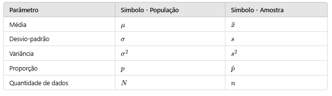

Diferenciação de Símbolos: Muitas vezes, ao trabalhar com estatística, é fácil confundir os símbolos. Saber diferenciar população e amostra é essencial para interpretar corretamente os resultados.

**OBS: Populações finitas**

Permitem a contagem de seus elementos. Como exemplos temos o número de funcionário de uma empresa, a quantidade de alunos em uma escola etc.

**OBS: Populações infinitas**

Não é possível contar seus elementos. Como exemplos temos a quantidade de porções que se pode extrair da água do mar para uma análise, temperatura medida em cada ponto de um território etc.

Quando os elementos de uma população puderem ser contados, porém apresentando uma quantidade muito grande, assume-se a população como infinita..

## 🔍 O que é Amostragem?

A amostragem é uma técnica estatística usada para selecionar uma **subconjunto de elementos** de uma população. O objetivo é fazer inferências sobre a população com base na amostra, economizando recursos e tempo.

## 📝 Quando Usar Amostragem?

- Populações infinitas: O estudo não chegaria nunca ao fim. Não é possível investigar todos os elementos da população.
- Testes destrutivos: Estudos onde os elementos avaliados são totalmente consumidos ou destruídos. Exemplo: testes de vida útil, testes de segurança contra colisões em automóveis.
- Resultados rápidos: Pesquisas que precisam de mais agilidade na divulgação. Exemplo: pesquisas de opinião, pesquisas que envolvam problemas de saúde pública. fazer uma pesquisa de opinião de eleição com a população toda seria a própria eleição
- Custos elevados: Quando a população é finita mas muito numerosa, o custo de um censo pode tornar o processo inviável.

## 📝 Por que Usar Amostragem?

- Economizar tempo e custo.
- Obter resultados rápidos.
- Garantir representatividade com tamanhos de amostra menores.

Testes de hipóteses são essenciais para a tomada de decisões informadas, usando dados amostrais para inferir resultados populacionais. A generalização dos resultados da amostra para a população é o que torna a inferência estatística tão poderosa, especialmente em áreas como business, saúde e ciências sociais.

## 🗂️ A importância de fazer bem a Amostragem

A amostragem é uma etapa fundamental ao trabalhar com dados, especialmente quando queremos generalizar conclusões para a população inteira. Muitas vezes, esse passo é negligenciado, o que pode resultar em viés e erros na análise. Escolher a amostra correta ajuda a evitar vieses e melhora a eficiência dos resultados.

- Generalização Correta: Se a amostra for mal selecionada, os resultados podem não refletir a realidade da população.
- Redução de Viés: Métodos probabilísticos ajudam a minimizar erros sistemáticos e vieses.
- Qualidade dos Resultados: Amostras bem planejadas aumentam a confiabilidade das inferências estatísticas.

## 😈 Viés na amostragem

**Caso da Pesquisa Eleitoral nos EUA (1936)**

- Contexto Histórico: A revista Literary Digest realizou uma pesquisa para prever o resultado da eleição presidencial dos EUA em 1936. A previsão foi que Alf Landon venceria com 57% dos votos, enquanto Franklin D. Roosevelt teria 43%. O resultado real foi 62% para Roosevelt e 38% para Landon.
- Problema: Viés na Amostragem. A pesquisa utilizou listas telefônicas e registros de automóveis para coletar os dados. Durante a Grande Depressão, essas fontes eram não representativas, pois apenas pessoas de maior renda tinham telefone e carro. Isso gerou um viés de amostragem, já que pessoas de menor poder aquisitivo (que apoiavam Roosevelt) não foram bem representadas.

## 📝 Tipos de Viés - Aleatório vs. Sistemático

**Viés Aleatório:**

- Diminui conforme o tamanho amostral aumenta.
- Ocorre por flutuações naturais no processo de amostragem.
- É causado por variações imprevisíveis.
- Exemplo: Ao sortear nomes de um saco, cada sorteio pode ser diferente.

**Viés Sistemático**

- Não é reduzido com o aumento do tamanho amostral.
- Causado por erros metodológicos ou de coleta.
- Exemplo: Coletar dados apenas em áreas urbanas e generalizar para uma população rural.

## 💭 Viés de amostragem

O viés de amostragem ocorre quando a seleção de uma amostra não representa adequadamente a população alvo, comprometendo a validade dos resultados de uma pesquisa ou estudo. Esse viés pode surgir de diversas formas, afetando a precisão das conclusões obtidas.

**Causas Comuns do Viés de Amostragem**

- Viés de Subcobertura: Descrição: Parte da população não tem chance de ser selecionada na amostra. Exemplo: Uma pesquisa de opinião política realizada apenas em bairros de alto poder aquisitivo. Problema: Grupos socioeconômicos mais pobres são subrepresentados, o que distorce os resultados. Impacto: A amostra não reflete a diversidade da população.
- Viés de Auto-Seleção: Descrição: Os participantes escolhem se querem ou não participar, o que atrai perfis específicos. Exemplo: Enquetes online sobre preferências de produto. Problema: Quem participa pode ter uma opinião mais forte ou interesse no tema, enquanto pessoas indiferentes não respondem. Impacto: Os resultados são enviesados em favor de quem tem uma posição clara, geralmente positiva ou negativa.
- Viés de Voluntariado: A amostra é formada por indivíduos que se voluntariam para participar. Exemplo: Pesquisas sobre qualidade de atendimento em que apenas clientes insatisfeitos respondem. Problema: A amostra se torna enviesada, representando apenas os casos extremos. Impacto: Resultados desproporcionais, geralmente indicando mais insatisfação ou satisfação do que realmente existe.
- Viés de Não-Resposta: Descrição: Parte dos indivíduos selecionados para a amostra não responde à pesquisa. Exemplo: Uma pesquisa eleitoral em que apenas eleitores de um determinado grupo político respondem. Problema: O viés ocorre porque os que não respondem podem ter opiniões significativamente diferentes. Impacto: A amostra não representa a opinião geral da população.
- Viés de Conveniência: Descrição: Seleciona os indivíduos mais facilmente acessíveis. Exemplo: Pesquisas realizadas apenas com estudantes universitários de uma única instituição. Problema: Não representam a diversidade da população, especialmente em estudos sociais. Impacto: Conclusões limitadas a um grupo específico, sem generalização.
- Viés Geográfico: Descrição: A amostra se concentra em uma região geográfica específica, ignorando outras. Exemplo: Pesquisas sobre hábitos alimentares feitas apenas em regiões metropolitanas. Problema: Habitantes de áreas rurais podem ter dietas e hábitos completamente diferentes. Impacto: A análise não reflete a realidade de áreas não amostradas.
- Viés de Frequência: Descrição: A amostragem ocorre em intervalos que coincidem com padrões repetitivos. Exemplo: Coletar dados sobre tráfego apenas em horários de pico. Problema: Os padrões de tráfego fora desses horários não são representados. Impacto: Superestima o fluxo de veículos e compromete a análise de padrões completos.
- Viés de Sobrevivência: Descrição: Focar apenas em casos bem-sucedidos ou sobreviventes, ignorando os que falharam. Exemplo: Estudos sobre longevidade que analisam apenas idosos vivos. Problema: Ignora pessoas que já faleceram, distorcendo a análise sobre hábitos saudáveis. Impacto: Os resultados superestimam a eficácia de práticas ou tratamentos.

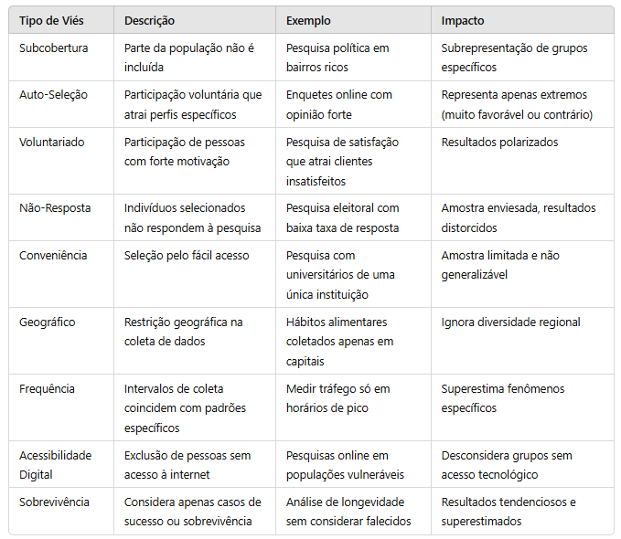

## 🗂️ Tipos de Amostragem

O viés de amostragem pode distorcer gravemente os resultados de uma análise estatística, levando a decisões equivocadas. Por isso, é fundamental planejar cuidadosamente a coleta e garantir a representatividade da amostra.

🧮 **Amostragem Probabilística:**

Cada elemento da população tem uma chance conhecida e não nula de ser selecionado. É considerada mais robusta e minimiza vieses, pois garante aleatoriedade.

Exemplos:

- Amostragem Aleatória Simples: Todos têm a mesma chance.
- Amostragem Estratificada: A população é dividida em grupos homogêneos.
- Amostragem Sistemática: Escolhe-se elementos em intervalos fixos.
- Amostragem por Conglomerado: Grupos heterogêneos são selecionados aleatoriamente.

🚩 **Amostragem Não Probabilística**:

A escolha dos elementos não segue um critério aleatório, o que pode introduzir viés significativo. Não podemos garantir que a amostra represente adequadamente a população. Problema: A seleção pode ser influenciada por preconceitos ou vieses pessoais.

Exemplos:

- Amostragem por Conveniência: Escolhe-se o que está mais fácil ou acessível.
- Amostragem por Julgamento: O especialista decide quais elementos são relevantes.

**Resumo dos Tipos de Amostragem**

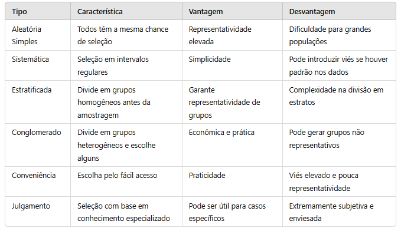

OBS: Sempre avalie a qualidade e representatividade da amostra antes de tirar conclusões. Verifique se há potenciais fontes de viés que possam distorcer os resultados.

```python
import pandas as pd
import numpy as np

# Criando um DataFrame de exemplo com 1000 elementos
np.random.seed(42)  # Para reprodutibilidade
populacao = pd.DataFrame({
    'ID': range(1, 1001),
    'Idade': np.random.randint(18, 65, size=1000),
    'Gênero': np.random.choice(['M', 'F'], size=1000),
    'Renda': np.random.normal(2500, 800, size=1000)
})

print("Dados de População:")
display(populacao.head())
```

```
Dados de População:
```

|  | ID | Idade | Gênero | Renda |
| --- | --- | --- | --- | --- |
| 0 | 1 | 56 | M | 2055.840379 |
| 1 | 2 | 46 | F | 4004.925656 |
| 2 | 3 | 32 | F | 1341.588880 |
| 3 | 4 | 60 | F | 740.955235 |
| 4 | 5 | 25 | M | 2852.011560 |

## 🧮 Amostragem Probabilística

### 🧮 Amostragem Aleatória Simples

Amostragem Aleatória Simples (SRS):

Seleciona elementos aleatoriamente da população, garantindo que todos tenham a mesma chance de serem escolhidos.

**Vantagens:**

- Fácil Implementação: Usando algoritmos simples (como a função sample() do Python), é possível realizar a seleção com poucos passos.
- Representatividade Estatística: Por ser totalmente aleatória, caracteriza muito bem a população, garantindo inferências robustas.

**Desvantagens:**

- Ausência de Categorias Raras: Se houver categorias pouco frequentes na população, elas podem não aparecer na amostra, prejudicando análises específicas.
- Custo e Logística: Para populações grandes, pode ser caro e demorado garantir que todos os elementos tenham a mesma chance.

```python
# 1. 📊 Amostragem Aleatória Simples
amostra_aleatoria = populacao.sample(n=100, random_state=42)
print("\n📊 Amostragem Aleatória Simples:")
display(amostra_aleatoria.head())
```

```
📊 Amostragem Aleatória Simples:
```

|  | ID | Idade | Gênero | Renda |
| --- | --- | --- | --- | --- |
| 521 | 522 | 25 | M | 3861.771956 |
| 737 | 738 | 38 | M | 2096.180063 |
| 740 | 741 | 34 | M | 2308.854321 |
| 660 | 661 | 38 | F | 1642.288790 |
| 411 | 412 | 61 | F | 2502.436816 |

### 🧮 Amostragem Sistemática

Amostragem Sistemática:

A amostragem sistemática consiste em selecionar um elemento inicial de forma aleatória e, a partir dele, escolher elementos a cada intervalo fixo (enésimo elemento) na população. Útil quando os dados estão ordenados.

**Vantagens:**

- Fácil Implementação: Simples de realizar e pouco sujeita a erros operacionais.
- Distribuição Uniforme: Garante que os elementos estejam distribuídos ao longo da população.
- Caracteriza Bem a População: Se a população for homogênea ou ordenada, representa bem o conjunto total.
- Mitiga o Problema de Amostras Raras: Quando o intervalo é bem definido, permite capturar grupos menos comuns.

**Desvantagens**:

- Padrão na População: Se houver um padrão cíclico nos dados, o método pode capturar apenas um subconjunto enviesado.
- Perda de Representatividade: Se algum elemento selecionado não puder ser usado (por exemplo, o quinto elemento não responder a uma pesquisa), pode prejudicar a representatividade.
- Rigidez na Escolha: Uma vez definido o ponto de partida e o intervalo, não há flexibilidade para ajustes.

```python
# 2. 📈 Amostragem Sistemática
# Define o intervalo de seleção: total da população dividido pelo tamanho da amostra
intervalo = len(populacao) // 100  # Tamanho da amostra: 100 elementos
# Seleciona elementos a cada 'intervalo' posições
indices = np.arange(0, len(populacao), intervalo)
amostra_sistematica = populacao.iloc[indices]
print("\n📈 Amostragem Sistemática:")
display(amostra_sistematica.head())  # Mostra as primeiras linhas da amostra
```

```
📈 Amostragem Sistemática:
```

|  | ID | Idade | Gênero | Renda |
| --- | --- | --- | --- | --- |
| 0 | 1 | 56 | M | 2055.840379 |
| 10 | 11 | 28 | M | 1475.756481 |
| 20 | 21 | 47 | F | 2307.011154 |
| 30 | 31 | 59 | F | 3014.178208 |
| 40 | 41 | 26 | F | 2602.483532 |

### 🧮 Amostragem Estratificada

Divide a população em estratos homogêneos e realiza a amostragem dentro de cada grupo. No exemplo, a estratificação foi feita por gênero.

**Vantagem:**

- Mitiga o Problema de Amostras Raras: Garante que grupos minoritários ou menos frequentes estejam representados na amostra.
- Maior Precisão Estatística: Aumenta a precisão das estimativas ao considerar a variabilidade dentro de cada estrato.
- Redução de Viés: Evita que algum grupo fique sub-representado ou completamente ausente.

**Desvantagem:**

- Complexidade na Estratificação: Muitas vezes, é difícil definir os estratos corretamente. Exemplo: Cargo e Senioridade em uma empresa podem se sobrepor, dificultando a segmentação.
- Grupos Múltiplos ou Cruzados: Alguns indivíduos podem pertencer a mais de um estrato, o que gera ambiguidade na seleção

```python
# 3. 🗂️ Amostragem Estratificada
from sklearn.model_selection import train_test_split

# Divide a população em estratos com base no gênero e seleciona 10% de cada grupo
amostra_estratificada = populacao.groupby('Gênero', group_keys=False).apply(lambda x: x.sample(frac=0.1))
print("\n🗂️ Amostragem Estratificada:")
display(amostra_estratificada.head())  # Mostra as primeiras linhas da amostra
```

```
🗂️ Amostragem Estratificada:
```

|  | ID | Idade | Gênero | Renda |
| --- | --- | --- | --- | --- |
| 396 | 397 | 51 | F | 1748.531685 |
| 607 | 608 | 30 | F | 2073.839328 |
| 475 | 476 | 40 | F | 1894.563929 |
| 570 | 571 | 24 | F | 3122.688861 |
| 457 | 458 | 46 | F | 3749.208957 |

### 🧮 Amostragem por Conglomerado

Divide a população em grupos heterogêneos e seleciona grupos inteiros de forma aleatória.

```python
# 4. 🏢 Amostragem por Conglomerado
# Divide a população em 10 conglomerados (grupos) numerados aleatoriamente de 1 a 10
populacao['Grupo'] = np.random.randint(1, 11, size=len(populacao))
# Escolhe aleatoriamente 3 conglomerados para compor a amostra
conglomerados_escolhidos = np.random.choice(populacao['Grupo'].unique(), size=3, replace=False)
# Seleciona todos os registros dos conglomerados escolhidos
amostra_conglomerado = populacao[populacao['Grupo'].isin(conglomerados_escolhidos)]
print("\n🏢 Amostragem por Conglomerado:")
display(amostra_conglomerado.head())  # Mostra as primeiras linhas da amostra
```

```
🏢 Amostragem por Conglomerado:
```

|  | ID | Idade | Gênero | Renda | Grupo |
| --- | --- | --- | --- | --- | --- |
| 2 | 3 | 32 | F | 1341.588880 | 2 |
| 4 | 5 | 25 | M | 2852.011560 | 3 |
| 10 | 11 | 28 | M | 1475.756481 | 8 |
| 13 | 14 | 57 | F | 2420.659309 | 2 |
| 14 | 15 | 41 | M | 3977.309597 | 3 |

## 🧮 Amostragem Não Probabilística

### 🧮 Amostragem por Conveniência ou Acidental

- Descrição: Seleção de elementos que estão mais acessíveis ou disponíveis.
- Quando Usar: Quando há limitações de tempo ou recursos.
- Exemplo: Coletar respostas apenas de quem está presente em um evento.
- Vantagem: Rápida e econômica.
- Desvantagem: Altamente enviesada e pouco representativa.

```python
# 5. 🤝 Amostragem por Conveniência
# Escolhe as 100 primeiras linhas da população como amostra (geralmente pouco recomendada)
amostra_conveniencia = populacao.head(100)
print("\n🤝 Amostragem por Conveniência:")
display(amostra_conveniencia.head())  # Mostra as primeiras linhas da amostra
```

```
🤝 Amostragem por Conveniência:
```

|  | ID | Idade | Gênero | Renda | Grupo |
| --- | --- | --- | --- | --- | --- |
| 0 | 1 | 56 | M | 2055.840379 | 1 |
| 1 | 2 | 46 | F | 4004.925656 | 7 |
| 2 | 3 | 32 | F | 1341.588880 | 2 |
| 3 | 4 | 60 | F | 740.955235 | 1 |
| 4 | 5 | 25 | M | 2852.011560 | 3 |

### 🧮 Amostragem por Julgamento ou Intencional

- Definição: A escolha da amostra depende do conhecimento especializado ou de critérios previamente estabelecidos.
- Quando Usar: Em estudos qualitativos ou quando se deseja obter opiniões de especialistas.
- Exemplo: Selecionar profissionais experientes para discutir a eficácia de um novo protocolo médico.
- Vantagem: Obtenção de informações valiosas e contextualizadas.
- Desvantagem: Altamente subjetivo e propenso a vieses.

```python
# 6. 🔍 Amostragem por Julgamento
# Seleciona manualmente elementos que atendem a um critério específico
# Neste exemplo, seleciona registros com idade acima de 50 anos e renda acima de 3000
amostra_julgamento = populacao[(populacao['Idade'] > 50) & (populacao['Renda'] > 3000)]
print("\n🔍 Amostragem por Julgamento:")
display(amostra_julgamento.head())  # Mostra as primeiras linhas da amostra
```

```
🔍 Amostragem por Julgamento:
```

|  | ID | Idade | Gênero | Renda | Grupo |
| --- | --- | --- | --- | --- | --- |
| 12 | 13 | 53 | F | 3020.160942 | 10 |
| 30 | 31 | 59 | F | 3014.178208 | 6 |
| 35 | 36 | 61 | F | 3652.093772 | 7 |
| 37 | 38 | 54 | F | 3940.752346 | 7 |
| 56 | 57 | 52 | F | 3702.718641 | 10 |

### 🧮 Amostragem por Quotas

- Definição: A seleção dos elementos segue uma quota previamente definida, geralmente para manter uma proporção.
- Quando Usar: Quando é necessário garantir diversidade representativa.
- Exemplo: Selecionar participantes em função de idade e gênero até atingir a quota estabelecida.
- Vantagem: Garante diversidade de grupos.
- Desvantagem: Pode ser enviesada se as quotas não forem bem definidas.

```python
# 5. 🌟 Amostragem por Quotas
quota_m = populacao[populacao['Gênero'] == 'M'].sample(n=40)
quota_f = populacao[populacao['Gênero'] == 'F'].sample(n=60)
amostra_quota = pd.concat([quota_m, quota_f])
print("\n🌟 Amostragem por Quotas:")
display(amostra_quota.head())
```

```
🌟 Amostragem por Quotas:
```

|  | ID | Idade | Gênero | Renda | Grupo |
| --- | --- | --- | --- | --- | --- |
| 73 | 74 | 31 | M | 1982.450578 | 10 |
| 715 | 716 | 19 | M | 2842.645678 | 8 |
| 176 | 177 | 42 | M | 2990.219124 | 4 |
| 292 | 293 | 63 | M | 3007.021505 | 7 |
| 885 | 886 | 20 | M | 1787.046220 | 3 |

## ✅ Como Mitigar o Viés de Amostragem

**Planejamento Cuidadoso: Definir claramente a população-alvo e as estratégias de coleta.**

O planejamento cuidadoso é essencial para garantir que a amostragem seja realizada de forma representativa e sem viés. Sem um plano claro, é fácil cometer erros que comprometem toda a análise estatística.

💡 Passos do Planejamento Cuidadoso:

- Definir a População-Alvo: Identificar quem ou o que será alvo da pesquisa. Exemplo: Pacientes com hipertensão em uma determinada cidade.
- Escolher a Técnica de Amostragem: Decidir se será probabilística ou não probabilística. Considerar as características da população e os recursos disponíveis.
- Determinar o Tamanho da Amostra: Calcular o número de indivíduos necessários para garantir precisão estatística. Utilizar fórmulas que considerem o nível de confiança e a margem de erro.
- Descrever o Procedimento de Coleta: Documentar como os dados serão coletados. Garantir a treinamento da equipe para seguir o protocolo de coleta.

🚀 Exemplo Prático: Em um estudo sobre o uso de medicamentos em pacientes crônicos, o planejamento cuidadoso permite definir: População-alvo: Todos os pacientes com diagnóstico de hipertensão atendidos em uma rede hospitalar. Técnica de Amostragem: Estratificada, garantindo representatividade por idade e gênero. Procedimento de Coleta: Entrevistas padronizadas com registro eletrônico.

**Diversificação de Fontes: Combinar métodos probabilísticos e não probabilísticos**

Combinar métodos ajuda a balancear representatividade e praticidade, especialmente em cenários onde o acesso a dados é limitado ou onde há restrições financeiras.

💡 Benefícios da Combinação:

- Equilíbrio entre Precisão e Rapidez: O método probabilístico garante representatividade.
- O método não probabilístico facilita a coleta rápida em situações emergenciais.
- Correção de Viés: Utilizar métodos probabilísticos para validar e corrigir amostras coletadas por conveniência ou julgamento.

🚀 Exemplo Prático: Em uma pesquisa de satisfação de pacientes: Primeira Fase (Não Probabilística): Coleta rápida com voluntários após a consulta. Segunda Fase (Probabilística): Amostragem aleatória estratificada para garantir diversidade. Combinação: Verificar se as respostas voluntárias representam a diversidade da população e ajustar conforme necessário.

**Amostragem Aleatória: Garantir que todos tenham a mesma chance de serem selecionados.**

A amostragem aleatória reduz o viés, garantindo que cada indivíduo tenha a mesma probabilidade de ser escolhido. Isso permite fazer inferências válidas para a população.

💡 Tipos de Amostragem Aleatória:

- Aleatória Simples: Todos têm a mesma chance de serem selecionados. Uso de sorteio ou algoritmo aleatório.
- Aleatória Sistemática: Escolhe elementos em intervalos regulares. Garantia de representação ao longo da população.

🚀 Exemplo Prático: Pesquisa sobre o consumo de alimentos ultraprocessados: População-alvo: Moradores de uma cidade. Técnica: Amostragem Aleatória Simples com sorteio por números aleatórios. Benefício: Todos os moradores têm a mesma probabilidade de serem incluídos.

**Estratificação: Dividir a população em grupos e garantir que cada um esteja representado.**

A estratificação evita que grupos minoritários sejam sub-representados, garantindo que cada subgrupo relevante da população esteja na amostra.

💡 Passos para Estratificação:

- Identificação dos Estratos: Grupos homogêneos que possuem características comuns (idade, gênero, classe social).
- Proporção de Cada Estrato: Calcular quantos indivíduos de cada grupo devem ser amostrados.
- Seleção Aleatória Dentro de Cada Estrato: Garantir que a amostra dentro de cada grupo também seja aleatória.

🚀 Exemplo Prático: Estudo epidemiológico sobre prevalência de diabetes: Estratos: Faixas etárias (18-30, 31-50, 51+). Proporcionalidade: Cada faixa deve estar representada conforme sua proporção na população. Garantia de Diversidade: Resultados mais robustos e confiáveis.

**Verificação Pós-Coleta: Analisar a amostra para identificar eventuais desequilíbrios.**

Mesmo após um bom planejamento, pode haver desequilíbrios na coleta. A verificação pós-coleta garante que a amostra realmente reflita a população-alvo.

💡 Como Verificar:

- Análise Descritiva: Calcular medidas estatísticas da amostra (média, mediana, desvio padrão).
- Comparar com os dados populacionais conhecidos. Validação da Representatividade:
- Conferir se os grupos populacionais (por idade, gênero, região) estão adequadamente representados.
- Ajustes Necessários: Se houver desbalanceamento, considerar técnicas como ponderação ou recoleta de dados.

🚀 Exemplo Prático: Após coletar dados de saúde mental em diferentes bairros, observa-se que alguns bairros de periferia estão sub-representados. Correção: Recoletar dados específicos nesses bairros para ajustar o peso relativo na amostra.